# StanMoMo

## Installation

To install `StanMoMo` from GitHub you will need `devtools`:

```r
install.packages("devtools")
devtools::install_github('kabarigou/StanMoMo')
```

After installing the package, you have to load the package via:

```r
library(StanMoMo)
```

# Introduction: Bayesian Lee-Carter with Stan

We first explain how to estimate the Lee-Carter model using the `lc_stan` function in the `StanMoMo` package.

For illustration, the package already includes the object `FRMaleData` containing deaths (`FRMaleData$Dxt`) and central exposures (`FRMaleData$Ext`) for French males for the period 1816-2017 and for ages 0-100. In our example, we concentrated on ages 50-90 and the period 1970-2017. This can be obtained via:

```r
ages.fit<-50:90
years.fit<-1970:2017
deathFR<-FRMaleData$Dxt[formatC(ages.fit),formatC(years.fit)]
exposureFR<-FRMaleData$Ext[formatC(ages.fit),formatC(years.fit)]
```

We note that the random walk with drift appears as a special case. The choice of priors can be found in the paper.

## Bayesian Estimation

Now, the model can be estimated and forecast for the next 10 years by a simple call to the `lc_stan` function:

```r
fitLC=lc_stan(death = deathFR,exposure=exposureFR, forecast = 10, family = "poisson",cores=4)
```

By default, Stan samples four Markov chains with 2000 iterations with 1000 warmup iterations for each chain (hence, 4000 draws in total). The output is an object of class `stanfit` (cf. the **rstan** package) which contains the posterior draws of each parameter, the posterior log likelihoods as well as the mortality forecasts.

The user can have access to an interface for interactive MCMC diagnostics and plots and tables helpful for analyzing posterior samples through the `shinystan` package.

```r
library(shinystan)
launch_shinystan(fitLC)
```

We can also plot the sampling for each parameter with the use of the `bayesplot` package. For instance, the posterior uncertainty intervals for

[figure not shown]

, for

[figure not shown]

, based on the 4000 draws can be obtained via

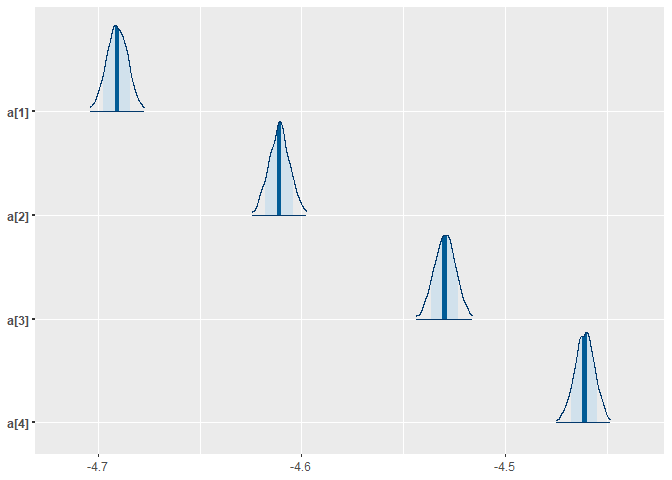

```r
library(bayesplot)
posterior <- as.array(fitLC)
mcmc_areas(posterior,pars = c("a[1]", "a[2]", "a[3]", "a[4]"),prob = 0.8, prob_outer = 0.99, point_est = "mean")
```

We can also use the output to produce fan charts depicting the uncertainty around each parameter of the model fit.

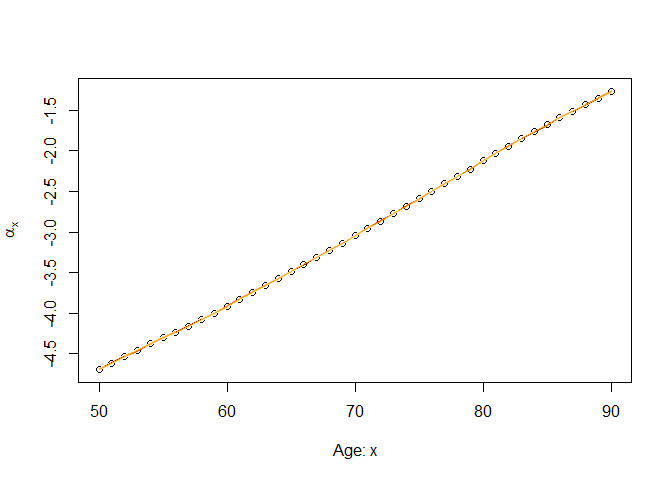

```r
library("fanplot")
library("RColorBrewer")
library(latex2exp)
params<-rstan::extract(fitLC)
#Alpha
plot(ages.fit, colMeans(params$a), ylim=range(params$a),ylab=TeX("$\\alpha_x$"), xlab="Age: x")
fan(data=params$a, start=ages.fit[1],type = "interval", ln=NULL,probs = seq(0.01,0.99,0.01),
    fan.col = colorRampPalette(colors = rev(brewer.pal(9,"Oranges"))))
```

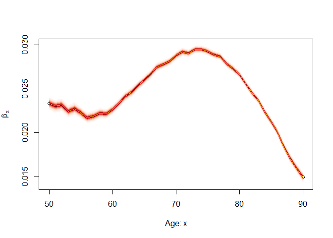

```r
#Beta
plot(ages.fit, colMeans(params$b), ylim=range(params$b),ylab=TeX("$\\beta_x$"), xlab="Age: x")
fan(data=params$b, start=ages.fit[1],type = "interval", ln = NULL,probs = seq(0.01,0.99,0.01),
    fan.col = colorRampPalette(colors = rev(brewer.pal(9,"Reds"))))
```

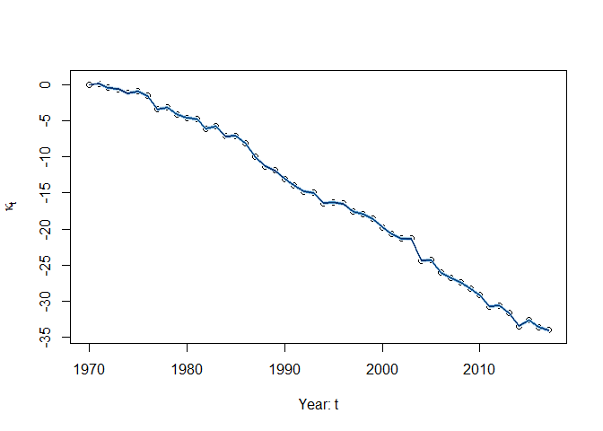

```r
#Kappa
plot(years.fit, colMeans(params$k), ylim=range(params$k),ylab=TeX("$\\kappa_t$"), xlab="Year: t")
fan(data=params$k, start=years.fit[1],type = "percentile",ln = NULL, probs = seq(0.01,0.99,0.01),
    fan.col = colorRampPalette(colors = rev(brewer.pal(9,"Blues"))))
```

## Forecasting

Predictions of death rates for the next 10 years with confidence intervals can be obtained as follows:

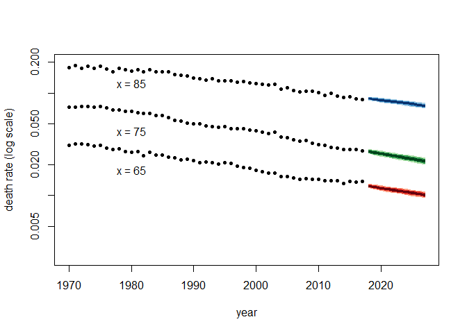

```r
# Resize the forecast deaths rates as an array "Number of draws X Ages X Years to predict"
samplesize<-4000
years.predict<-2018:2027
pred<-array(params$mufor,dim=list(samplesize,length(ages.fit),length(years.predict)),
            dimnames = list(c(1:samplesize),formatC(ages.fit),formatC(years.predict)))
#Fan plots for ages 65,75,85
probs = c(2.5, 10, 25, 50, 75, 90, 97.5)
qxt <- deathFR / exposureFR
matplot(years.fit, t(qxt[c("65", "75", "85"), ]),
        xlim = c(1970, 2027), ylim = c(0.0025, 0.2), pch = 20, col = "black",
        log = "y", xlab = "year", ylab = "death rate (log scale)")
fan(pred[,"65" , ], start = 2018, probs = probs, n.fan = 4,
    fan.col =  colorRampPalette(colors = rev(brewer.pal(9,"Reds"))), ln = NULL)
fan(pred[,"75" , ], start = 2018, probs = probs, n.fan = 4,
    fan.col =  colorRampPalette(colors = rev(brewer.pal(9,"Greens"))), ln = NULL)
fan(pred[,"85" , ], start = 2018, probs = probs, n.fan = 4,
    fan.col =  colorRampPalette(colors = rev(brewer.pal(9,"Blues"))), ln = NULL)
text(1980, qxt[c("65", "75", "85"), "2000"],
     labels = c("x = 65", "x = 75", "x = 85"))
```

# Other models

In a similar fashion, the models RH, APC, CBD and M6 can be fitted with the following calls:

```r
fitRH=rh_stan(death = deathFR,exposure=exposureFR, forecast = 10, family = "poisson",cores=4)
fitAPC=apc_stan(death = deathFR,exposure=exposureFR, forecast = 10, family = "poisson",cores=4)
fitCBD=cbd_stan(death = deathFR,exposure=exposureFR, age=ages.fit, forecast=10,family = "poisson",cores=4)
fitM6=m6_stan(death = deathFR,exposure=exposureFR, age=ages.fit,forecast = 10, family = "poisson",cores=4)
```

# Bayesian model averaging

The package also includes the `mortality_weights` function which performs Bayesian model averaging via future-out cross-validation. The weights are obtained by stacking of predictive distributions and Pseudo-BMA weighting, based on Yao et al. (2018) but adapted for mortality forecasting in our paper. Roughly speaking, the last

[figure not shown]

years of data are left out and the weights search for the optimal mortality model on these last

[figure not shown]

[figure not shown]

```r
fitLC=lc_stan(death = deathFR,exposure=exposureFR, forecast = 20, validation=10,family = "poisson",cores=4)
fitRH=rh_stan(death = deathFR,exposure=exposureFR, forecast = 20, validation=10,family = "poisson",cores=4)
fitAPC=apc_stan(death = deathFR,exposure=exposureFR, forecast = 20, validation=10,family = "poisson",cores=4)
fitCBD=cbd_stan(death = deathFR,exposure=exposureFR, age=ages.fit, forecast=10,validation=10,family = "poisson",cores=4)
fitM6=m6_stan(death = deathFR,exposure=exposureFR, age=ages.fit,forecast = 20, validation=10,family = "poisson",cores=4)
model_weights<-mortality_weights(list(fitLC,fitRH,fitAPC,fitCBD,fitM6))
```

## Fit with a negative-binomial

All the models can be fitted with a Negative-Binomial distribution with the argument `family="nb"`.